# GEOPHYS 218Y Assignment 1

Brian Amaro

1/18/2022

The East Palo Alto OPA debate is one of great topical and local importance. Those supporting the policy, largely current renters, advocate for how this policy benefits those in the community as it helps limit the displacement of tenants yet aiming to not be overly restrictive on current homeowners. Those against the policy, largely current homeowners, have various concerns including how this policy may affect housing prices, add other unnecessary burdens to those selling homes, and ultimately not fundamentally solve the housing inequity issue at hand.

[interactive chart not shown]

Before delving into my views, one noteworthy insight about this debate is that, as we can see in the map above,the distribution of homeowners vs renters seems to be quite homogeneous in terms of geographical location. This is therefore not an issue that can be resolved through some sort of sectional policy; rather, it is an issue that affects the community as a whole.

When I first informed myself of this debate, I was largely in favor of the policy. This is largely because I was and am convinced that housing inequity is a large problem in East Palo Alto.

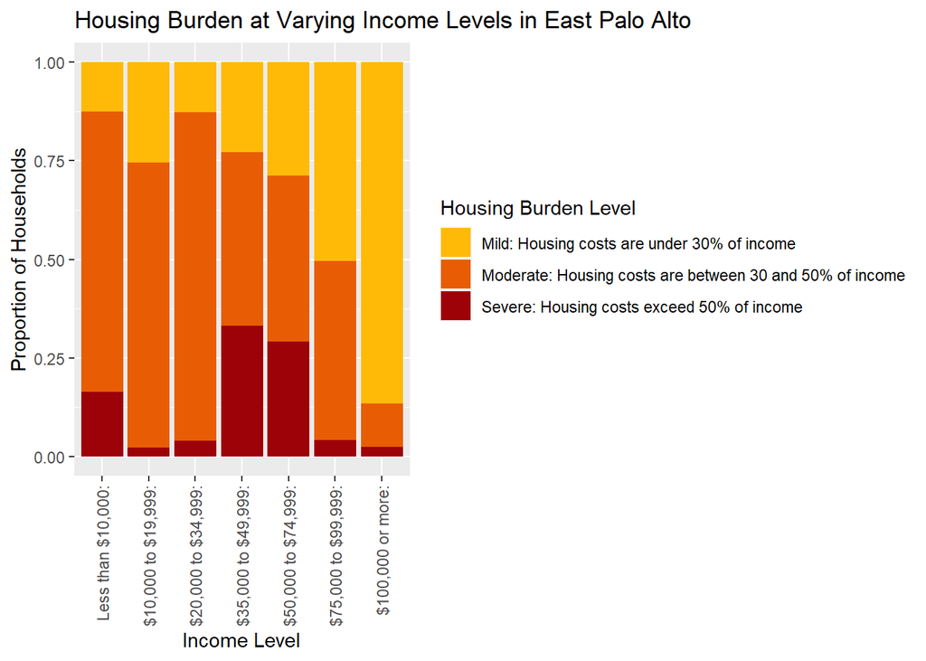

We can see in that chart above, created using ACS data, that East Palo Alto remains much too expensive for a large proportion of its residents, particularly those that have an annual household income below $100,000. Additionally one can see that the housing burden is falling particularly to renters. Analysis of the ACS data shows us that 67% of severely burdened households are renter-occupied (while only 59% of all housing units in East Palo Alto are renter-occupied). Looking into San Mateo property tax data and analyzing several characteristics of single family housing at the parcel level further confirms the unfortunate situation of renters.

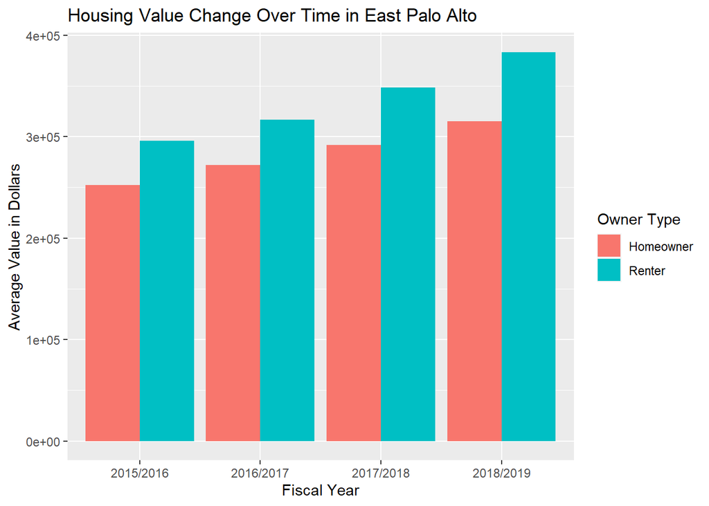

The chart above shows how housing value has been steadily increasing in recent years, especially renter-occupied properties. This will only increase the housing burden for renters, further showing the need for home equity policy in East Palo Alto.

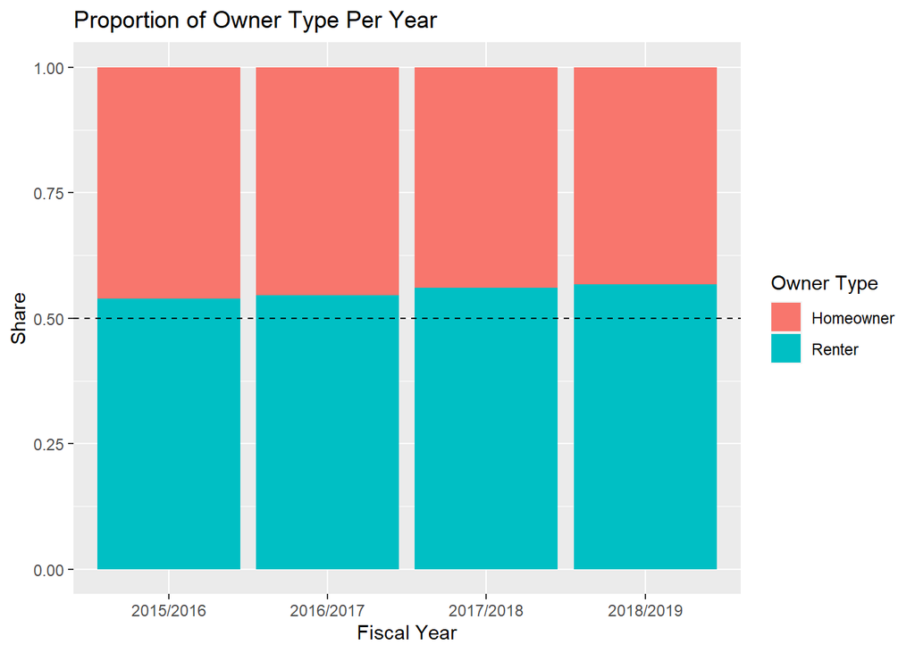

The chart above also confirms the narrative that those in favor of the policy recount in how properties are being increasingly occupied by renters. OPA would likely shift this trend in the opposite direction by allowing more renters to become homeowners, and thus keeping East Palo Alto residents in East Palo Alto. Additionally, this chart shows how renter-owned properties make up the majority of single-family housing, supporting the idea that pro-renter policies are beneficial to the majority of the community.

In light of all this evidence as well as other material I have reviewed, my personal opinion regarding the East Palo Alto OPA debate has somewhat shifted towards being slightly against this policy. While I am thoroughly convinced that there is a major housing inequity problem in East Palo Alto, I have yet to be convinced that this is the right path to take in solving that problem. Particularly, I have not been convinced that this policy will meaningfully solve these problems while not also placing an undue burden on homeowners through the addition unnecessary bureaucratic measures. Ultimately, I believe I would need to see more analysis specific to the effects of OPA-policies, likely in the form of extending the analysis of the effects of other similar policies passed in other locations.

A preliminary example of such analysis would include addressing the concern held by homeowners that the OPA policy would worsen the housing market in East Palo Alto by looking at how housing prices were affected when a similar policy (TOPA) was passed in Washington D.C. in 1980.

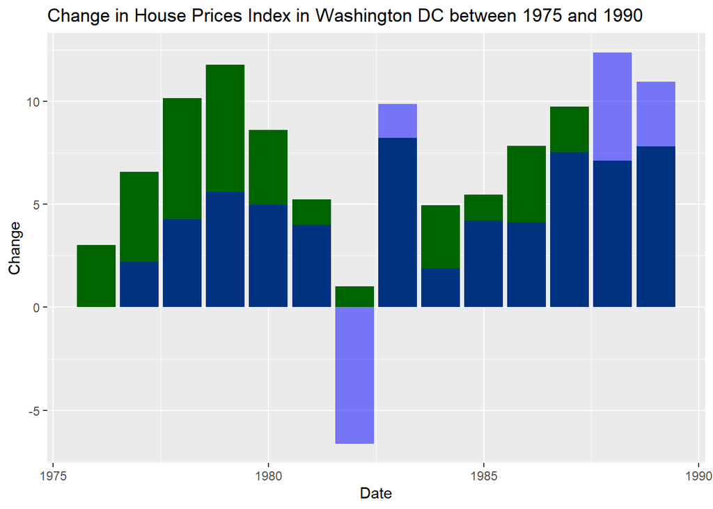

Looking forward, I believe it is this sort of comparative analysis that should be extended in order to help resolve the debate surround OPA in East Palo Alto.